# MI Economic Indicator Report

Justin Baker

April 10, 2019

## Reporting Time!

Now let’s take everything we’ve learned and generate a report. But before we begin, a few notes.

#### A Note About Style

You may notice some differences between the way Alicia, Ryan and I have written some things in our code. There are many ways to do many things in R, so naturally everyone’s code may end up looking a little different.

One way to make sure everyone’s code isn’t too different is to implement a programming style guide in your organization. In the Office of Good Government at the State of Michigan, we use [Google’s R Style Guide](https://google.github.io/styleguide/Rguide.xml), with a few modifications. That helps make sure everyone can read everyone else’s code.

#### Do It Yourself!

I’ve used some data from `future.michigan.gov`, our open performance site. But I strongly encourage you to visit your own Open Data Portal and find some data that you know well to build charts of your own!

Okay, back to the report!

## Packages

Before we begin, let’s make sure we’ve installed all the packages we’ll need. If you haven’t installed the following packages, head over to the console and run `install.packages("package_name")`.

```r
#### Libraries ####
# Libraries
library(flexdashboard)
library(tidyverse)
library(RSocrata)
library(readxl)
library(lubridate)
#### Options ####
options(tz="US/Michigan")  # might be req for read.socrata()
knitr::opts_chunk$set(fig.width=16, fig.height=8)
```

## Unemployment Data

Next, we’ll practice what Alicia and Ryan have just shown us - we’ll pull, clean, and transform datasets from Socrata and Excel to create the data that will generate our report.

Notice that our Socrata data is pulled through the Socrata API. This means that if I want to update this report in the future, all I need to do is re-run the code chunks, and all of my visualizations will automatically update.

## Michigan Economic Indicators

### Unemployment

| date | Location | unemp_rate |
| --- | --- | --- |
| 1976-01-01 | MI | 9.9 |
| 1976-02-01 | MI | 9.9 |
| 1976-03-01 | MI | 9.9 |
| 1976-04-01 | MI | 9.8 |
| 1976-05-01 | MI | 9.6 |
| 1976-06-01 | MI | 9.4 |
| 1976-07-01 | MI | 9.2 |
| 1976-08-01 | MI | 9.1 |
| 1976-09-01 | MI | 9.0 |
| 1976-10-01 | MI | 9.0 |

[output cut: 990 more lines]

### Labor Underutilization

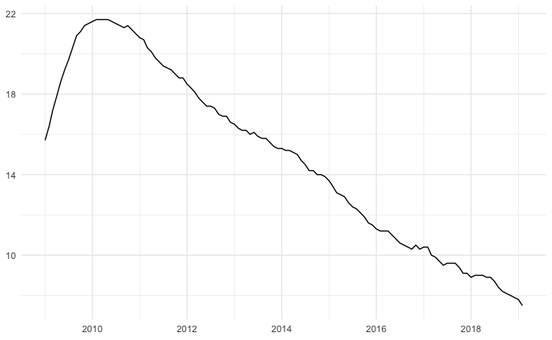

```r
econ %>%
  # U-6 has some NA - let's get rid of those
  filter(!is.na(u_6)) %>%
  ggplot(aes(date, u_6)) +
    geom_line() +
    theme_som()
```

### Labor Force

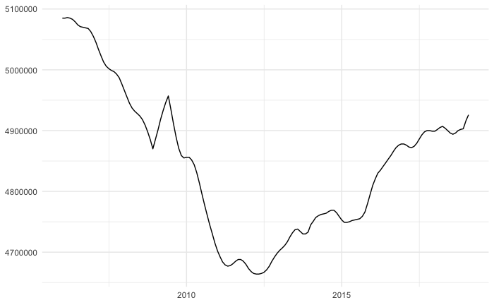

```r
econ %>%
  ggplot(aes(date, labor_force)) +
  geom_line() +
  theme_som()
```

### Labor Force Participation Rate

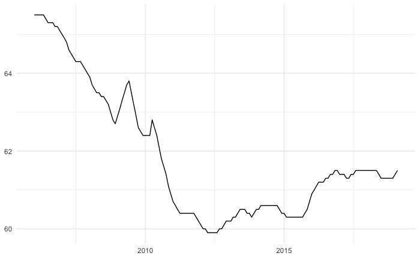

```r
econ %>%
  ggplot(aes(date, labor_force_participation_rate)) +
  geom_line() +
  theme_som()
```